# bài tập 3

Nguyễn Quốc Bảo

2025-01-11

Bài tập 3. Có 46 vụ tràn dầu thô với khối lượng ít nhất là 1000 thùng từ tàu chở dầu trên vùng biển Hoa Kỳ trong giai đoạn 1974-1999. Tập tin oilspills.dat chứa dữ liệu sau:

- year : năm thứ i;
- spills : số vụ tràn dầu Ni trong năm thứ i;
- importexport : lượng dầu ước tính được vận chuyển qua vùng biển Hoa Kỳ như một phần của hoạt động xuất nhập khẩu của Hoa Kỳ trong năm thứ i, được điều chỉnh cho sự cố tràn ở vùng biển quốc tế hoặc nước ngoài, $b_{i1}$ ;
- domestic : lượng dầu được vận chuyển qua vùng biển Hoa Kỳ trong các chuyến hàng trong nước trong năm thứ i, $b_{i2}$.

# Read Data

```r
dataset <- read.table("/home/baron/BaoBao/master_2024/Statistical_Computing/dataset/oilspills.dat", header = TRUE)
data <- list(N=dataset$spills, b1=dataset$importexport, b2=dataset$domestic)
```

#### (a) Xác định hàm log-likelihood cho các hệ số $\alpha_1$ và $\alpha_2$.

Hàm mật độ của phân phối Poisson là:

$$P(N_i = n_i | \lambda) = \frac{\lambda_i^{n_i} e^{-\lambda_i}}{n_i!}$$

trong đó:

- $\lambda_i = \alpha_1 b_{i1} + \alpha_2 b_{i2}$ là kỳ vọng số vụ tràn dầu trong năm thứ phụ thuộc vào các tham số $\alpha_1$ và $\alpha_2$
- $N_i$ là số vụ tràn dầu trong năm thứ $i$
- $b_{i1}$ và $b_{i2}$ lần lượt là lượng dầu vận chuyển quốc tế và trong nước.

Hàm likelihood là:
$$L(\alpha_1, \alpha_2) = \prod_{i=1}^{n} P(N_i = n_i | \alpha_1, \alpha_2) = \prod_{i=1}^{n} \frac{\lambda_i^{n_i} e^{-\lambda_i}}{n_i!}$$

Hàm log-likelihood là:
$$\log L(\alpha_1, \alpha_2) = \sum_{i=1}^{n} \log P(N_i = n_i | \alpha_1, \alpha_2) = \sum_{i=1}^{n} \log \left( \frac{\lambda_i^{n_i} e^{-\lambda_i}}{n_i!} \right)$$
$$\log L(\alpha_1, \alpha_2) = \sum_{i=1}^{n} \left( n_i \log \lambda_i - \lambda_i - \log n_i! \right)$$

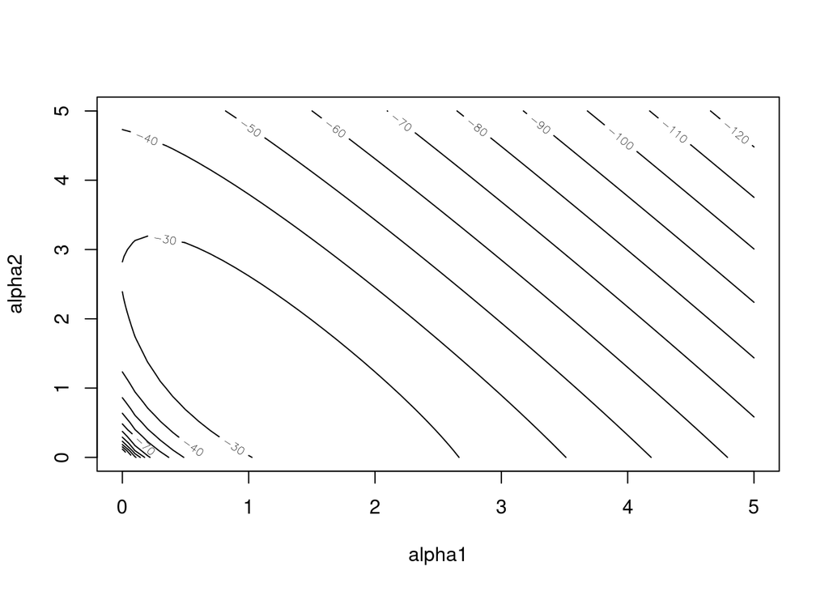

```r
# lambda function
lambda <- function(alpha1, alpha2, data) {
    return(alpha1 * data$b1 + alpha2 * data$b2)
}

# log-likelihood function
log_likelihood <- function(alpha1, alpha2, data) {
    lambda_i <- lambda(alpha1, alpha2, data)
    return(sum(log(lambda_i) * data$N - lambda_i))
}

# plot log-likelihood
alpha1 <- seq(0, 5, by = 0.1)
alpha2 <- seq(0, 5, by = 0.1)

logL_matrix <- matrix(0, nrow = length(alpha1), ncol = length(alpha2))

for(i in 1:length(alpha1)) {
    for(j in 1:length(alpha2)) {
        logL_matrix[i, j] <- log_likelihood(alpha1[i], alpha2[j], data)
    }
}
contour(alpha1, alpha2, logL_matrix, nlevels = 10, xlab = "alpha1", ylab = "alpha2")
```

#### (b) Viết các bước giải thuật để xác định ước lượng MLE của $\alpha_1$ và $\alpha_2$ bằng phương pháp Newton. Viết một chương trình thi hành giải thuật này.

Bước 1: Tính đạo hàm của hàm log-likelihood

$$\frac{\partial \log L(\alpha_1, \alpha_2)}{\partial \alpha_1} = \sum_{i=1}^{n} (\frac{b_{i1} n_i}{\lambda_i} - b_{i1})$$

$$\frac{\partial \log L(\alpha_1, \alpha_2)}{\partial \alpha_2} = \sum_{i=1}^{n} (\frac{b_{i2} n_i}{\lambda_i} - b_{i2})$$

Bước 2: Tính đạo hàm cấp 2 của hàm log-likelihood

$$\frac{\partial^2 \log L(\alpha_1, \alpha_2)}{\partial \alpha_1^2} = \sum_{i=1}^{n} (- \frac{b_{i1}^2 n_i}{\lambda_i^2})$$

$$\frac{\partial^2 \log L(\alpha_1, \alpha_2)}{\partial \alpha_1 \partial \alpha_2} = \sum_{i=1}^{n} (-\frac{b_{i1} b_{i2} n_i}{\lambda_i^2})$$

$$\frac{\partial^2 \log L(\alpha_1, \alpha_2)}{\partial \alpha_2^2} = \sum_{i=1}^{n} (-\frac{b_{i2}^2 n_i}{\lambda_i^2})$$

Bước 3: triển khai phương pháp Newton

$$\begin{pmatrix}
\frac{\partial^2 \log L(\alpha_1, \alpha_2)}{\partial \alpha_1^2} & \frac{\partial^2 \log L(\alpha_1, \alpha_2)}{\partial \alpha_1 \partial \alpha_2} \\
\frac{\partial^2 \log L(\alpha_1, \alpha_2)}{\partial \alpha_2 \partial \alpha_1} & \frac{\partial^2 \log L(\alpha_1, \alpha_2)}{\partial \alpha_2^2}
\end{pmatrix}
\begin{pmatrix}
\Delta \alpha_1 \\
\Delta \alpha_2
\end{pmatrix} = -\begin{pmatrix}
\frac{\partial \log L(\alpha_1, \alpha_2)}{\partial \alpha_1} \\
\frac{\partial \log L(\alpha_1, \alpha_2)}{\partial \alpha_2}
\end{pmatrix}$$

Bước 4: cập nhật $\theta = (\alpha_1, \alpha_2)$ và lặp lại cho đến khi hội tụ

$$\theta^{(t+1)} = \theta^{(t)} - H^{-1} \nabla \log L(\theta^{(t)})$$

```r
log_likelihood_prime <- function(alpha1, alpha2, data) {
    lambda_i <- lambda(alpha1, alpha2, data)
    grad1 <- sum(data$N * data$b1 / lambda_i - data$b1)
    grad2 <- sum(data$N * data$b2 / lambda_i - data$b2)
    return(c(grad1, grad2))
}

log_likelihood_2prime <- function(alpha1, alpha2, data) {
    lambda_i <- lambda(alpha1, alpha2, data)
    h11 <- sum(-data$N * (data$b1^2) / lambda_i^2)
    h22 <- sum(-data$N * (data$b2^2) / lambda_i^2)
    h12 <- sum(-data$N * (data$b1 * data$b2) / lambda_i^2)
    return(matrix(c(h11, h12, h12, h22), nrow = 2, ncol = 2, byrow = TRUE))
}

newton_raphson <- function(alpha_init, data, max_iter = 100, tol = 1e-4) {
    alpha <- alpha_init
    vals <- matrix(NA, nrow = max_iter + 1, ncol = 2)
    vals[1, ] <- alpha
    for(i in 1:max_iter) {
        gradient <- log_likelihood_prime(alpha[1], alpha[2], data)
        hessian <- log_likelihood_2prime(alpha[1], alpha[2], data)
        update <- solve(hessian) %*% gradient
        alpha <- alpha - as.numeric(update)
        vals[i + 1, ] <- alpha
        if (sqrt(sum(update^2)) < tol) break
    }
    return(list(alpha=alpha, vals=vals))
}

alpha_init <- c(0.1, 0.2)
alpha_mle_newton <- newton_raphson(alpha_init, data)
# contour(alpha1, alpha2, logL_matrix, nlevels = 10, xlab = "alpha1", ylab = "alpha2")
# points(alpha_mle_newton$vals[, 1], alpha_mle_newton$vals[, 2], pch = 16, type = "b")
print(alpha_mle_newton$alpha)
```

```
[1] 1.0971525 0.9375546
```

#### (c) Viết các bước giải thuật để xác định ước lượng MLE của $\alpha_1$ và $\alpha_2$ bằng phương pháp Fisher Scoring. Viết một chương trình thi hành giải thuật này. So sánh với kết quả câu (b).

Công thức Fisher Scoring:

$$\theta^{(t+1)} = \theta^{(t)} + I^{-1}(\theta^{(t)}) \nabla L(\theta^{(t)})$$

trong đó:

- $\theta = (\alpha_1, \alpha_2)$
- $I(\theta^{(t)}) = E[-\nabla^2 \log L(\theta^{(t)})]$ là ma trận thông tin Fisher

```r
fisher_information <- function(alpha1, alpha2, data) {
    lambda_i <- lambda(alpha1, alpha2, data)
    I_11 <- sum(data$N * (data$b1^2) / lambda_i^2)
    I_12 <- sum(data$N * (data$b1 * data$b2) / lambda_i^2)
    I_22 <- sum(data$N * (data$b2^2) / lambda_i^2)
    fisher_matrix <- matrix(c(I_11, I_12, I_12, I_22), nrow = 2, ncol = 2)
    return(fisher_matrix)
}

# Fisher Scoring method
fisher_scoring <- function(data, alpha_init, tol = 1e-3, max_iter = 100) {
    alpha <- alpha_init
    vals <- matrix(NA, nrow = max_iter + 1, ncol = 2)
    vals[1, ] <- alpha
    for (iter in 1:max_iter) {
        grad <- log_likelihood_prime(alpha[1], alpha[2], data)
        fisher_info <- fisher_information(alpha[1], alpha[2], data)
        update <- solve(fisher_info) %*% grad
        alpha <- alpha + as.vector(update)
        vals[iter + 1, ] <- alpha
        if (sqrt(sum(update^2)) < tol) break
    }
    return(list(alpha=alpha, vals=vals))
}

alpha_init <- c(0.3, 0.1)
alpha_mle_fisher <- fisher_scoring(data, alpha_init)
# contour(alpha1, alpha2, logL_matrix, nlevels = 10, xlab = "alpha1", ylab = "alpha2")
# points(alpha_mle_fisher[1], alpha_mle_fisher[2], pch = 16, type = "b")
print(alpha_mle_fisher$alpha)
```

```
[1] 1.0971525 0.9375546
```

```r
difference <- abs(alpha_mle_newton$alpha - alpha_mle_fisher$alpha)
print(paste("Difference in alpha1:", difference[1]))
```

```
[1] "Difference in alpha1: 1.51945123150199e-12"
```

```r
print(paste("Difference in alpha2:", difference[2]))
```

```
[1] "Difference in alpha2: 5.79414294321623e-12"
```

#### (d) Ước lượng sai số chuẩn (standard errors) của ước lượng MLE.

```r
compute_se <- function(alpha, data) {
    I <- fisher_information(alpha[1], alpha[2], data)
    cov_matrix <- solve(I)
    se <- sqrt(diag(cov_matrix))
    return(se)
}

alpha_init <- c(0.1, 0.1)
se_newton <- compute_se(alpha_mle_newton$alpha, data)
se_fisher <- compute_se(alpha_mle_fisher$alpha, data)
print(paste("Standard errors (Newton):", se_newton))
```

```
[1] "Standard errors (Newton): 0.389612939615646"
[2] "Standard errors (Newton): 0.554675998181441"
```

```r
print(paste("Standard errors (Fisher):", se_fisher))
```

```
[1] "Standard errors (Fisher): 0.389612939615587"
[2] "Standard errors (Fisher): 0.554675998180521"
```

#### (e) Áp dụng phương pháp quasi-Newton với hai cách chọn $M^{(0)}$ : (1) ma trận đơn vị âm và (2) ma trận thông tin Fisher, $-I(\alpha^{(0)})$ . So sánh tính ổn định, tốc độ của hai cách chọn này.

Công thức Quasi-Newton:
$$\theta^{t+1} = \theta^{t} - \alpha^{t} (M^{(t)})^{-1} \nabla l(\theta^{(t)})$$
trong đó:

- $\theta = (\alpha_1, \alpha_2)$

$$M^{(t+1)} = M^{(t)} - \frac{M^{(t)} h^{(t)} (h^{(t)} M^{(t)})^T }{(h^{(t)})^T M^{(t)} h^{(t)}} + \frac{u^{(t)} (u^{(t)})^T}{(h^{(t)})^T u^{(t)}}$$
trong đó:

- $h^{(t)} = \theta^{(t+1)} - \theta^{(t)}$
- $u^{(t)} = \nabla l(\theta^{(t+1)}) - \nabla l(\theta^{(t)})$
- $M$ là ma trận xác định dương

```r
# Quasi-Newton BFGS method
quasi_newton_bfgs <- function(data, alpha_init, M, tol = 1e-6, max_iter = 100) {
    alpha <- alpha_init
    learning_rate <- 1
    vals <- matrix(0, nrow = max_iter + 1, ncol = 2)
    vals[1, ] <- alpha

    for (iter in 1:max_iter) {
        grad <- log_likelihood_prime(alpha[1], alpha[2], data)

        # Kiểm tra ma trận Fisher Information M có xác định dương không
        if (any(eigen(M)$values <= 0)) {
            M <- M + diag(rep(tol, 2))  # Thêm epsilon vào đường chéo nếu M không xác định dương
        }

        update <- solve(M) %*% grad
        alpha_new <- alpha - learning_rate * update

        # Kiểm tra alpha_new có hợp lệ không
        if (any(alpha_new <= 0)) {
            print("Warning: alpha_new có giá trị âm, điều chỉnh learning_rate")
            learning_rate <- learning_rate / 2
            next
        }

        f_t <- log_likelihood(alpha_new[1], alpha_new[2], data)
        f_t0 <- log_likelihood(alpha[1], alpha[2], data)

        # Kiểm tra NaN
        if (is.nan(f_t)) {
            print("NaN encountered in log-likelihood calculation, adjusting step size")
            learning_rate <- learning_rate / 2
            next
        }

        # Giảm learning rate nếu f_t < f_t0
        while (f_t < f_t0) {
            learning_rate <- learning_rate / 2
            alpha_new <- alpha - learning_rate * update
            f_t <- log_likelihood(alpha_new[1], alpha_new[2], data)

            if (is.nan(f_t) || learning_rate < 1e-6) {
                print("Stopping due to NaN or very small learning rate")
                return(list(alpha = alpha, vals = vals))
            }
        }

        # Cập nhật ma trận M theo phương pháp BFGS
        ht <- alpha_new - alpha
        ut <- log_likelihood_prime(alpha_new[1], alpha_new[2], data) - grad
        v <- ut - M %*% ht
        M_old <- M
        M <- M - ((M %*% ht %*% t(M %*% ht)) / as.numeric(t(ht) %*% M %*% ht)) +
            ((ut %*% t(ut)) / as.numeric(t(ht) %*% ut))

        # Kiểm tra điều kiện cập nhật M
        if (abs((t(v) %*% ht)[1]) < tol) {
            M <- M_old
        }

        # Kiểm tra hội tụ
        if (sqrt(sum(update^2)) < tol) {
            print(paste("Converged at iteration", iter))
            break
        }

        # Cập nhật alpha
        alpha <- alpha_new
        vals[iter + 1, ] <- alpha
    }

    if (iter == max_iter) {
        print(paste("Not converged after", max_iter, "iterations"))
    }

    return(list(alpha = alpha, vals = vals))
}
```

Chọn $M = \begin{pmatrix} -1 & 0 \\0 & -1 \end{pmatrix}$

```r
# Initial parameters
alpha_init <- c(0.3, 0.3)
M <- -diag(length(alpha_init))
# Run Quasi-Newton BFGS method
alpha_mle_quasi_newton_bfgs_identify <- quasi_newton_bfgs(data, alpha_init, M, tol = 1e-6, max_iter = 1000)
```

```
[1] "Converged at iteration 406"
```

```r
# Plot results
# contour(alpha1, alpha2, logL_matrix, nlevels = 10, xlab = "alpha1", ylab = "alpha2")
# points(alpha_mle_quasi_newton_bfgs_identify$vals[, 1], alpha_mle_quasi_newton_bfgs_identify$vals[, 2], pch = 16, type = "b")
print(alpha_mle_quasi_newton_bfgs_identify$alpha)
```

```
          [,1]
[1,] 1.0971533
[2,] 0.9375551
```

Chọn $M = -I(\alpha^{(0)})$ là ma trận Fisher thông tin ban đầu.

```r
# Initial parameters
alpha_init <- c(0.3, 0.3)
M <- -fisher_information(alpha_init[1], alpha_init[2], data)
# Run Quasi-Newton BFGS method
alpha_mle_quasi_newton_bfgs_fisher <- quasi_newton_bfgs(data, alpha_init, M, max_iter = 1000)
```

```
[1] "Converged at iteration 15"
```

```r
# Plot results
# contour(alpha1, alpha2, logL_matrix, nlevels = 10, xlab = "alpha1", ylab = "alpha2")
# points(alpha_mle_quasi_newton_bfgs_fisher$vals[, 1], alpha_mle_quasi_newton_bfgs_fisher$vals[, 2], pch = 16, type = "b")
print(alpha_mle_quasi_newton_bfgs_fisher$alpha)
```

```
          [,1]
[1,] 1.0971526
[2,] 0.9375544
```

## (f) Xây dựng một đồ thị biểu diễn vùng tối ưu của hàm log-likelihood và để so sánh các đường đi được thực hiện bởi các phương pháp được sử dụng trong (b), (c) và (e). Chọn vùng vẽ đồ thị và điểm bắt đầu để minh họa tốt nhất các tính năng về hiệu suất của thuật toán.

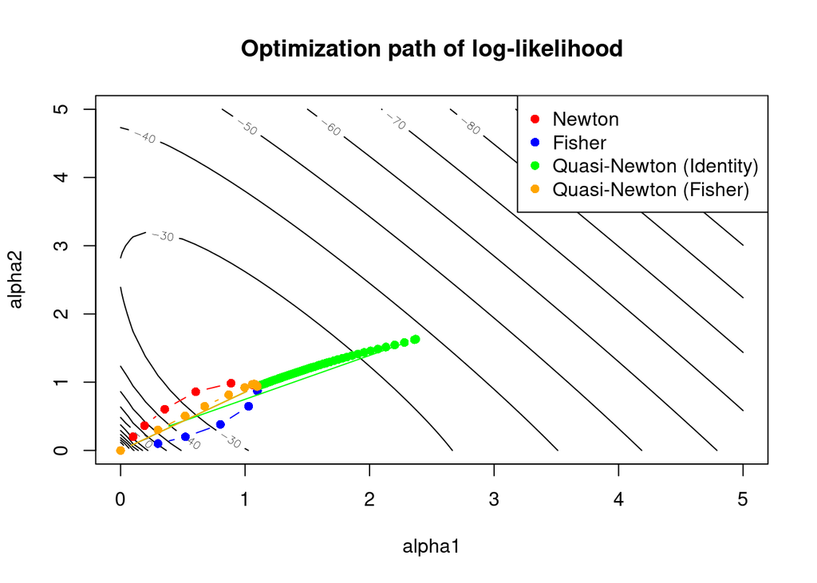

```r
# Plot results
contour(alpha1, alpha2, logL_matrix, nlevels = 10, xlab = "alpha1", ylab = "alpha2", main = "Optimization path of log-likelihood")
points(alpha_mle_newton$vals[,1], alpha_mle_newton$vals[,2], pch = 16, col = "red", type = "b")
points(alpha_mle_fisher$vals[,1], alpha_mle_fisher$vals[,2], pch = 16, col = "blue", type = "b")
points(alpha_mle_quasi_newton_bfgs_identify$vals[,1], alpha_mle_quasi_newton_bfgs_identify$vals[,2], pch = 16, col = "green", type = "b")
points(alpha_mle_quasi_newton_bfgs_fisher$vals[,1], alpha_mle_quasi_newton_bfgs_fisher$vals[,2], pch = 16, col = "orange", type = "b")
legend("topright", legend = c("Newton", "Fisher", "Quasi-Newton (Identity)", "Quasi-Newton (Fisher)"), col = c("red", "blue", "green", "orange"), pch = 16)
```